# Healthcare - CSE4068

## J Comp

Team Members:

Lokesh Kanna - 19MIA1014

Yuvashree R - 19MIA1053

Niharika Samyuktha - 19MIA1083

**Dataset Description**

The Pima Indian Diabetes data set consists of:

Pregnancies: Number of times pregnant

Glucose: Plasma glucose concentration a 2 hours in an oral glucose tolerance test

BloodPressure: Diastolic blood pressure (mm Hg)

SkinThickness: Triceps skin fold thickness (mm)

Insulin: 2-Hour serum insulin (mu U/ml)

BMI: Body mass index (weight in kg/(height in m)^2)

DiabetesPedigreeFunction: Diabetes pedigree function

Age: Age (years)

Outcome: Class variable (0 or 1) 268 of 768 are 1, the others are 0

## Load Libraries

```python
import pandas as pd
import numpy as np

import seaborn as sns
import matplotlib.pyplot as plt
from matplotlib import rcParams

from sklearn import model_selection
from sklearn.model_selection import train_test_split
from sklearn.metrics import accuracy_score, precision_score, recall_score, roc_auc_score
from sklearn.metrics import f1_score, confusion_matrix, precision_recall_curve, roc_curve
from sklearn.metrics import ConfusionMatrixDisplay
from sklearn.preprocessing import StandardScaler


import plotly.express as px
from plotly.subplots import make_subplots
import plotly.graph_objects as go

import warnings
warnings.filterwarnings(action='ignore')
```

## Defining Utility functions

```python
def get_clf_eval(y_test, pred=None, pred_proba=None):
    confusion = confusion_matrix( y_test, pred)
    accuracy = accuracy_score(y_test , pred)
    precision = precision_score(y_test , pred)
    recall = recall_score(y_test , pred)
    f1 = f1_score(y_test,pred)

    roc_auc = roc_auc_score(y_test, pred_proba)

    # ROC-AUC print
    print('accuracy: {0:.4f}, precision: {1:.4f}, recall: {2:.4f},\
    F1: {3:.4f}, AUC:{4:.4f}'.format(accuracy, precision, recall, f1, roc_auc))
    return confusion
```

Reading and Checking data

```python
diabetes_df = pd.read_csv("/content/diabetes.csv")
diabetes_df.head().T.style.set_properties(**{'background-color': 'grey',
                           'color': 'white',
                           'border-color': 'white'})
```

|  | 0 | 1 | 2 | 3 | 4 |
| --- | --- | --- | --- | --- | --- |
| Pregnancies | 6.000000 | 1.000000 | 8.000000 | 1.000000 | 0.000000 |
| Glucose | 148.000000 | 85.000000 | 183.000000 | 89.000000 | 137.000000 |
| BloodPressure | 72.000000 | 66.000000 | 64.000000 | 66.000000 | 40.000000 |
| SkinThickness | 35.000000 | 29.000000 | 0.000000 | 23.000000 | 35.000000 |
| Insulin | 0.000000 | 0.000000 | 0.000000 | 94.000000 | 168.000000 |
| BMI | 33.600000 | 26.600000 | 23.300000 | 28.100000 | 43.100000 |
| DiabetesPedigreeFunction | 0.627000 | 0.351000 | 0.672000 | 0.167000 | 2.288000 |
| Age | 50.000000 | 31.000000 | 32.000000 | 21.000000 | 33.000000 |
| Outcome | 1.000000 | 0.000000 | 1.000000 | 0.000000 | 1.000000 |

```python
diabetes_df.rename(columns ={"DiabetesPedigreeFunction":"DPF"},inplace=True)
```

# EDA

### Checking Missing Values and Data type

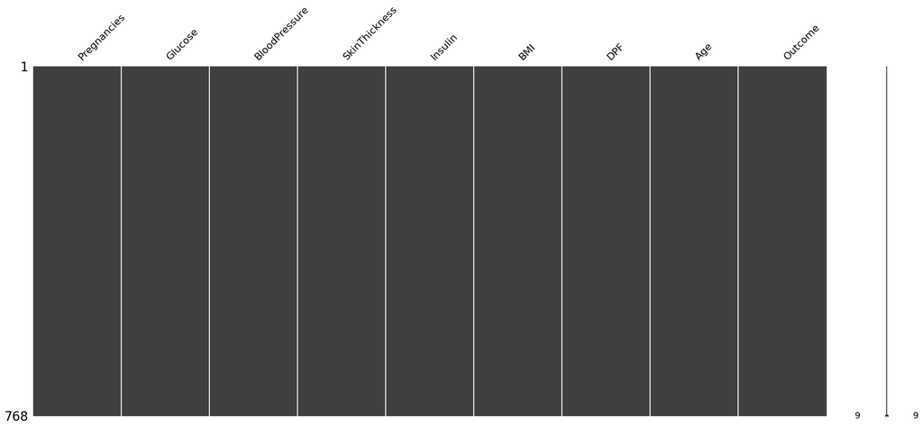

```python
import missingno as msno
msno.matrix(diabetes_df)
```

The msno.matrix() function is then used to generate a matrix plot that displays the missingness patterns in the diabetes_df DataFrame.A white cell indicates a missing value in the corresponding observation for the corresponding variable, while a black cell indicates the presence of a non-missing value.

There is no missing value and all features type are number. Therefore, there is no need to preprocess for missing values.

### Checking Target Imbalance

```python
colors = ['purple', 'red']
labels = ['0','1']
values = diabetes_df['Outcome'].value_counts()/diabetes_df['Outcome'].shape[0]

# Use `hole` to create a donut-like pie chart
fig = go.Figure(data=[go.Pie(labels=labels, values=values, hole=.3)])
fig.update_traces(hoverinfo='label+percent', textinfo='percent', textfont_size=20,
                  marker=dict(colors=colors, line=dict(color='#000000', width=2)))
fig.update_layout(
    title_text="Outcome")
fig.show()
```

[interactive chart not shown]

### Checking Statistics

```python
def highlight_min(s, props=''):
    return np.where(s == np.nanmin(s.values), props, '')

diabetes_df.describe().style.apply(highlight_min, props='color:Black;background-color:Grey', axis=0)
```

|  | Pregnancies | Glucose | BloodPressure | SkinThickness | Insulin | BMI | DPF | Age | Outcome |
| --- | --- | --- | --- | --- | --- | --- | --- | --- | --- |
| count | 768.000000 | 768.000000 | 768.000000 | 768.000000 | 768.000000 | 768.000000 | 768.000000 | 768.000000 | 768.000000 |
| mean | 3.845052 | 120.894531 | 69.105469 | 20.536458 | 79.799479 | 31.992578 | 0.471876 | 33.240885 | 0.348958 |
| std | 3.369578 | 31.972618 | 19.355807 | 15.952218 | 115.244002 | 7.884160 | 0.331329 | 11.760232 | 0.476951 |
| min | 0.000000 | 0.000000 | 0.000000 | 0.000000 | 0.000000 | 0.000000 | 0.078000 | 21.000000 | 0.000000 |
| 25% | 1.000000 | 99.000000 | 62.000000 | 0.000000 | 0.000000 | 27.300000 | 0.243750 | 24.000000 | 0.000000 |
| 50% | 3.000000 | 117.000000 | 72.000000 | 23.000000 | 30.500000 | 32.000000 | 0.372500 | 29.000000 | 0.000000 |
| 75% | 6.000000 | 140.250000 | 80.000000 | 32.000000 | 127.250000 | 36.600000 | 0.626250 | 41.000000 | 1.000000 |
| max | 17.000000 | 199.000000 | 122.000000 | 99.000000 | 846.000000 | 67.100000 | 2.420000 | 81.000000 | 1.000000 |

The code calculates descriptive statistics for each numerical column in the diabetes_df DataFrame using the describe() method, and then applies a custom function highlight_min() to highlight the minimum value in each column.

From the statistics, we can see that some features have minimum values of 0, which does not make sense (e.g. Glucose, BloodPressure, SkinThickness, Insulin, and BMI). These values need to be treated as missing values and imputed accordingly. Also, the standard deviation of some features is quite high, indicating that they may have outliers.

### Checking and Removing Outliers

```python
feature_names = [cname for cname in diabetes_df.loc[:,:'Age'].columns]
```

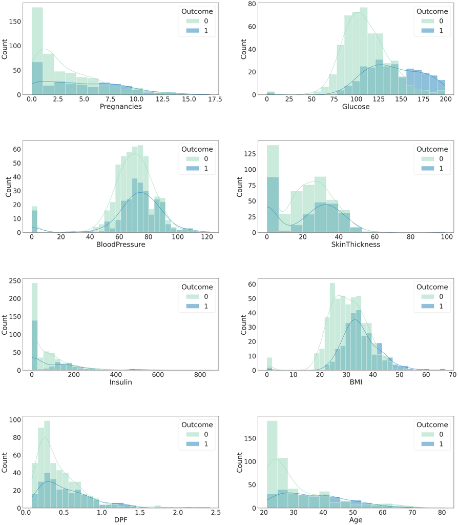

```python
rcParams['figure.figsize'] = 40,60
sns.set(font_scale = 3)
sns.set_style("white")
sns.set_palette("bright")
plt.subplots_adjust(hspace=0.5)
i = 1;
for name in feature_names:
    plt.subplot(5,2,i)
    sns.histplot(data=diabetes_df, x=name, hue="Outcome",kde=True,palette="YlGnBu")
    i = i + 1
```

The code is generates a set of histograms for each feature in the dataset, with the histograms colored according to the value of the "Outcome" column. This can help identify potential outliers and the distribution of each feature within the dataset.

Looking at the pictures above, it would be good to change the zero value of each feature to another value. First, let's calculate the proportion of zero values in each feature

```python
zero_features = ['Pregnancies','Glucose','BloodPressure','SkinThickness',"Insulin",'BMI']
total_count = diabetes_df['Glucose'].count()

for feature in zero_features:
    zero_count = diabetes_df[diabetes_df[feature]==0][feature].count()
    print('{0} 0 number of cases {1}, percent is {2:.2f} %'.format(feature, zero_count, 100*zero_count/total_count))
```

```
Pregnancies 0 number of cases 111, percent is 14.45 %
Glucose 0 number of cases 5, percent is 0.65 %
BloodPressure 0 number of cases 35, percent is 4.56 %
SkinThickness 0 number of cases 227, percent is 29.56 %
Insulin 0 number of cases 374, percent is 48.70 %
BMI 0 number of cases 11, percent is 1.43 %
```

Based on the proportion of zero values in each feature, it seems that SkinThickness and Insulin have a high number of missing values represented as zero. It might not be appropriate to remove all these rows since they represent a significant portion of the dataset. Instead, we can consider imputing these missing values using method mean imputation.

```python
diabetes_mean = diabetes_df[zero_features].mean()
diabetes_df[zero_features]=diabetes_df[zero_features].replace(0, diabetes_mean)
```

```python
X = diabetes_df.iloc[:,:-1]
y = diabetes_df.iloc[:,-1]
```

### Scaling

Although the zero values of each feature are converted to mean values, some features have a one-sided shape. Therefore, we decided to perform nonlinear scaling, and decided to use the QuantileTransformer that changes the distribution closest to the normal distribution.

The quantile function ranks or smooths out the relationship between observations and can be mapped onto other distributions, such as the uniform or normal distribution.

```python
from sklearn.preprocessing import QuantileTransformer
scaler = QuantileTransformer(n_quantiles=100, random_state=0, output_distribution='normal')
X_scaled = scaler.fit_transform(X)
```

```python
X_train, X_test, y_train, y_test = train_test_split(X, y, test_size=0.25, random_state=42)
```

```python
def highlight_min(s, props=''):
    return np.where(s == np.nanmin(s.values), props, '')

X_train.describe().style.apply(highlight_min, props='color:Black;background-color:Grey', axis=0)
```

|  | Pregnancies | Glucose | BloodPressure | SkinThickness | Insulin | BMI | DPF | Age |
| --- | --- | --- | --- | --- | --- | --- | --- | --- |
| count | 576.000000 | 576.000000 | 576.000000 | 576.000000 | 576.000000 | 576.000000 | 576.000000 | 576.000000 |
| mean | 4.315407 | 121.709154 | 72.144653 | 26.341978 | 118.600098 | 32.315027 | 0.468618 | 32.921875 |
| std | 2.916151 | 30.080570 | 12.113756 | 9.158041 | 94.570101 | 6.878494 | 0.339325 | 11.507539 |
| min | 1.000000 | 44.000000 | 24.000000 | 8.000000 | 14.000000 | 18.200000 | 0.078000 | 21.000000 |
| 25% | 2.000000 | 100.000000 | 64.000000 | 20.536458 | 79.799479 | 27.275000 | 0.240000 | 24.000000 |
| 50% | 3.845052 | 118.000000 | 72.000000 | 23.000000 | 79.799479 | 32.000000 | 0.372500 | 29.000000 |
| 75% | 6.000000 | 138.250000 | 80.000000 | 32.000000 | 127.500000 | 36.325000 | 0.612250 | 40.000000 |
| max | 17.000000 | 199.000000 | 122.000000 | 63.000000 | 846.000000 | 67.100000 | 2.420000 | 81.000000 |

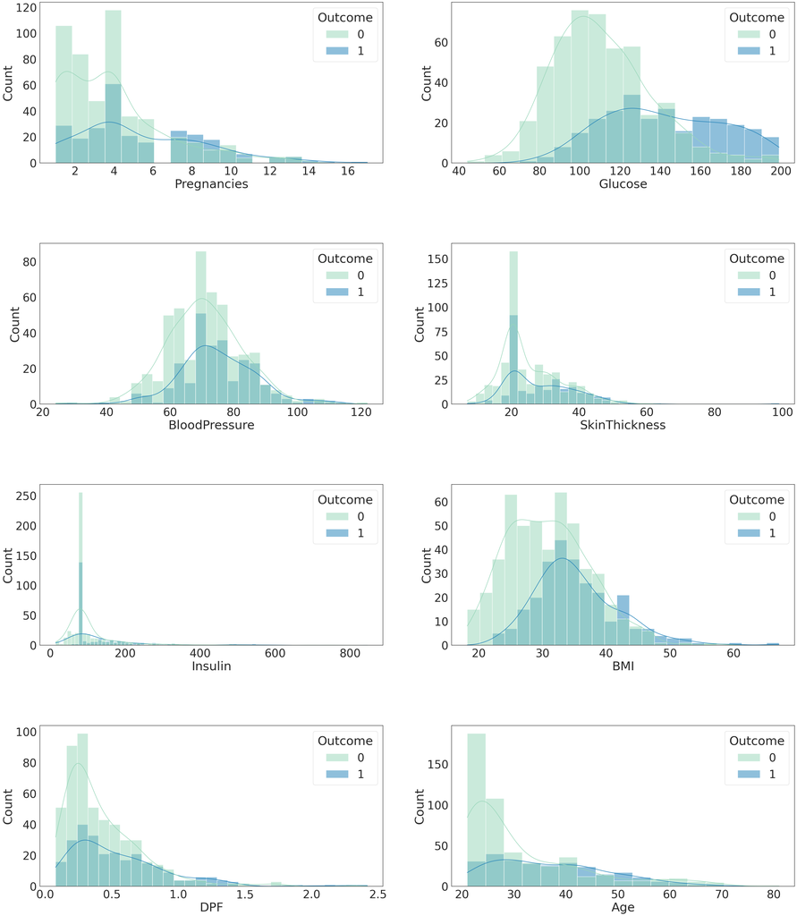

```python
rcParams['figure.figsize'] = 40,60
sns.set(font_scale = 3)
sns.set_style("white")
sns.set_palette("bright")
plt.subplots_adjust(hspace=0.5)
i = 1;
for name in feature_names:
    plt.subplot(5,2,i)
    sns.histplot(data=diabetes_df, x=name, hue="Outcome",kde=True,palette="YlGnBu")
    i = i + 1
```

### Checking correlation between features

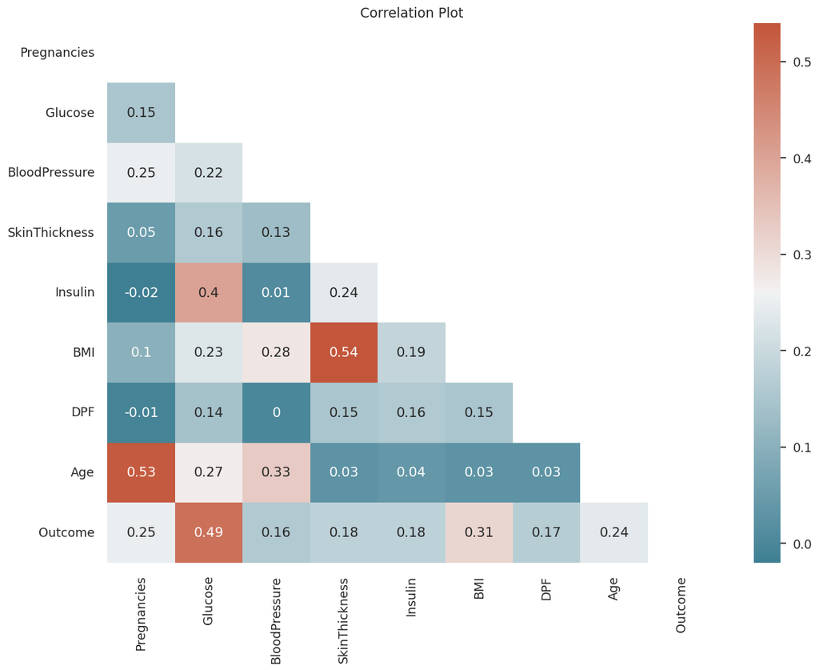

```python
corr = diabetes_df.corr().round(2)

sns.set(font_scale=1.15)
plt.figure(figsize=(14, 10))
sns.set_palette("bright")
sns.set_style("white")

mask = np.zeros_like(corr)
mask[np.triu_indices_from(mask)] = True

cmap = sns.diverging_palette(220, 20, as_cmap=True)

sns.heatmap(corr, annot=True, mask=mask, cmap=cmap, cbar=True)

plt.title('Correlation Plot')
```

BMI has a moderate positive correlation with SkinThickness, which may indicate that people with a higher BMI tend to have thicker skin.

The highest correlation values are between BMI and skin thickness (0.54), age and pregnancies (0.53), and outcome and glucose (0.49).

The other correlations are relatively weak or close to zero, such as insulin and pregnancies (-0.02), dpf and pregnancies (-0.01)

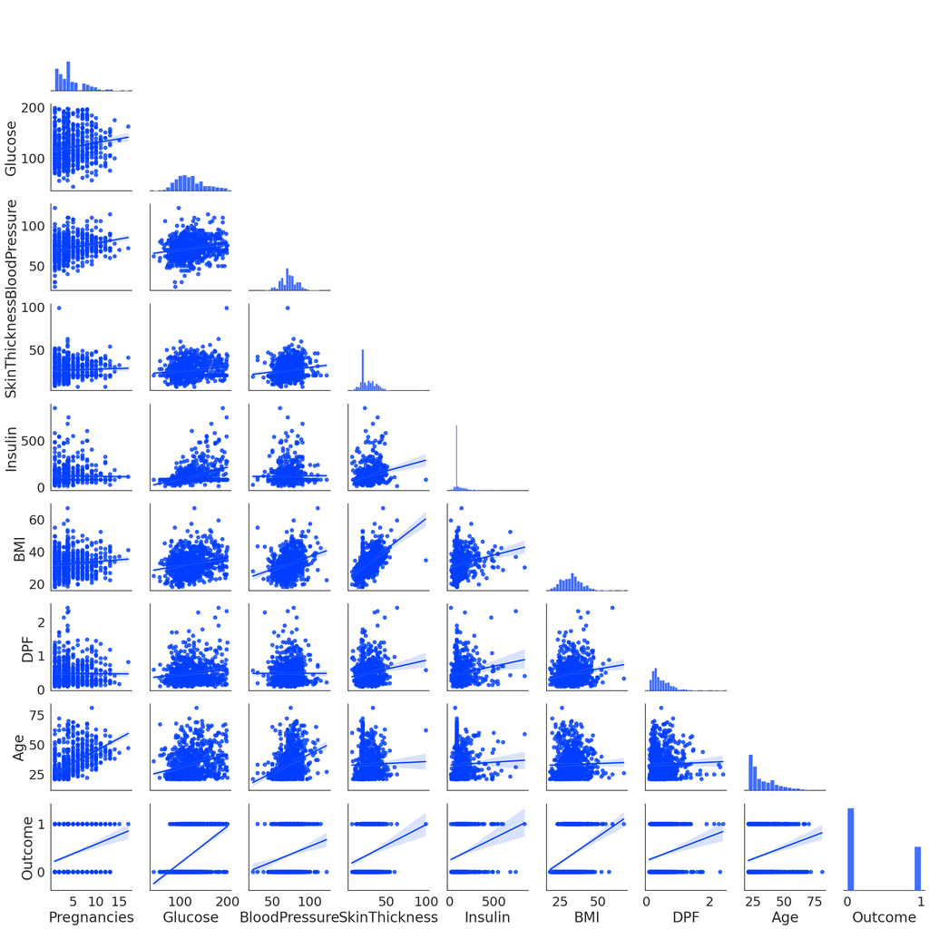

```python
sns.set(font_scale=2)
plt.figure(figsize=(10, 8))
sns.set_style("white")
sns.set_palette("bright")
sns.pairplot(diabetes_df,kind = 'reg',corner = True,palette ='YlGnBu' )
```

Observation:

The correlation between Outcome and Glucose is high. Glucose seems to be the most important feature in model training. BMI, Pregnancies, and Age are also expected to be used as important features in model training. There is a strong correlation between BMI and SkinThickness, which is not surprising as BMI is calculated based on weight and height, and SkinThickness is a measure of subcutaneous fat

## Features

```python
fig = px.histogram(diabetes_df, x="Glucose",
                   color="Outcome",
                   marginal="box",
                   barmode ="overlay",
                   histnorm ='density'
                  )
fig.update_layout(
    title_font_color="black",
    legend_title_font_color="green",
    title={
        'text': "Glucose Histogram per Outcome",
        'x':0.5,
        'xanchor': 'center',
        'yanchor': 'top'},
)
fig.show()
```

[interactive chart not shown]

```python
import plotly.express as px
fig = px.histogram(diabetes_df, x="BMI",
                   color="Outcome",
                   marginal="box",
                   barmode ="overlay",
                   histnorm ='density'
                  )
fig.update_layout(
    title_font_color="black",
    legend_title_font_color="green",
    title={
        'text': "BMI Histogram per Outcome",
        'x':0.5,
        'xanchor': 'center',
        'yanchor': 'top'},
)
fig.show()
```

[interactive chart not shown]

```python
import plotly.express as px
fig = px.histogram(diabetes_df, x="Age",
                   color="Outcome",
                   marginal="box",
                   barmode ="overlay",
                   histnorm ='density'
                  )
fig.update_layout(
    title_font_color="black",
    legend_title_font_color="green",
    title={
        'text': "Age Histogram per Outcome",
        'x':0.5,
        'xanchor': 'center',
        'yanchor': 'top'},
)
fig.show()
```

[interactive chart not shown]

From the above figures, you can see what distribution each feature has for each output. The glucose feature seems to have a clear distinction between the two outcomes, with the distribution for outcome 1 shifted to higher values compared to outcome 0. This indicates that glucose levels could be a strong predictor of diabetes outcome.

Similarly, for BMI, the distribution for outcome 1 is shifted towards higher values compared to outcome 0, indicating that high BMI could also be a potential risk factor for diabetes. Overall, these histograms provide valuable insights into the relationship between features and outcomes in the dataset.

## Visualizing Training Dataset after Dimension Reduction

```python
X_train = diabetes_df.drop('Outcome',axis=1)
y_train = diabetes_df['Outcome']
```

## 2D plot

```python
#!pip install umap-learn
```

```python
#pip install pandas matplotlib datashader bokeh holoviews scikit-image colorcet
```

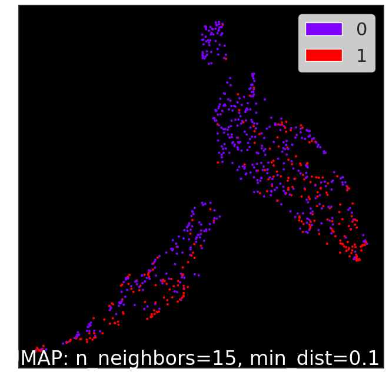

```python
import umap
import umap.plot

mapper = umap.UMAP().fit(X_train)
umap.plot.points(mapper, labels=y_train, theme='fire')
```

The 8-dimensional training dataset shown in the figure above is drawn by reducing the dimensions to 2D. As you can see in the figure, positive and negative are overlapped at the bottom of the figure. Since our models are mainly tree-based models, we will mainly work on determining the boundary, but it seems to be a difficult task in 2D.

However, our training dataset is 8-dimensional, just that we can't visualize it. Therefore, it will not be a very difficult task for our models to determine the boundary as shown above.

## 3D plot

```python
from umap import UMAP

umap_3d = UMAP(n_components=3, init='random', random_state=0)
x_umap = umap_3d.fit_transform(X_train)
umap_df = pd.DataFrame(x_umap)
train_y_sr = pd.Series(y_train,name='label').astype(str)
print(type(x_umap))
new_df = pd.concat([umap_df,train_y_sr],axis=1)
fig = px.scatter_3d(
    new_df, x=0, y=1, z=2,
    color='label', labels={'color': 'number'}
)
fig.update_traces(marker_size=1.5)
fig.show()
```

```
<class 'numpy.ndarray'>
```

[interactive chart not shown]

Even if you increase the dimension to 3D, you can see overlapping points.

# Ensemble

```python
#pip install pycaret
```

```python
from pycaret.classification import *
```

### Setup

```python
clf1 = setup(data = diabetes_df, target = 'Outcome',preprocess = False)
```

|  | Description | Value |
| --- | --- | --- |
| 0 | Session id | 7340 |
| 1 | Target | Outcome |
| 2 | Target type | Binary |
| 3 | Original data shape | (768, 9) |
| 4 | Transformed data shape | (768, 9) |
| 5 | Transformed train set shape | (537, 9) |
| 6 | Transformed test set shape | (231, 9) |
| 7 | Numeric features | 8 |

## Comparing Models

This function trains and evaluates performance of all estimators available in the model library using cross validation. The output of this function is a score grid with average cross validated scores.

```python
# create a list of models to exclude from the comparison
exclude_models = ['lightgbm', 'xgboost', 'svm', 'ridge', 'knn', 'dt', 'nb', 'qda']

# compare the remaining models and select the top 5 based on AUC score
top5 = compare_models(sort='AUC', n_select=5, exclude=exclude_models)
```

|  | Model | Accuracy | AUC | Recall | Prec. | F1 | Kappa | MCC | TT (Sec) |
| --- | --- | --- | --- | --- | --- | --- | --- | --- | --- |
| lr | Logistic Regression | 0.7766 | 0.8383 | 0.5708 | 0.7460 | 0.6373 | 0.4810 | 0.4963 | 0.7550 |
| lda | Linear Discriminant Analysis | 0.7766 | 0.8374 | 0.5708 | 0.7441 | 0.6375 | 0.4809 | 0.4955 | 0.0740 |
| catboost | CatBoost Classifier | 0.7617 | 0.8362 | 0.6088 | 0.6833 | 0.6396 | 0.4631 | 0.4680 | 3.1260 |
| rf | Random Forest Classifier | 0.7876 | 0.8315 | 0.6295 | 0.7253 | 0.6700 | 0.5153 | 0.5209 | 0.7940 |
| et | Extra Trees Classifier | 0.7690 | 0.8276 | 0.6085 | 0.6941 | 0.6450 | 0.4754 | 0.4802 | 1.0240 |
| gbc | Gradient Boosting Classifier | 0.7616 | 0.8228 | 0.6137 | 0.6802 | 0.6408 | 0.4636 | 0.4685 | 0.5980 |
| ada | Ada Boost Classifier | 0.7429 | 0.8065 | 0.5977 | 0.6442 | 0.6165 | 0.4242 | 0.4274 | 0.7460 |
| dummy | Dummy Classifier | 0.6518 | 0.5000 | 0.0000 | 0.0000 | 0.0000 | 0.0000 | 0.0000 | 0.0470 |

Logistic Regression with an AUC score of 0.8383

Linear Discriminant Analysis with an AUC score of 0.8374

Extra Trees Classifier with an AUC score of 0.8276

Creating Models

```python
#pip install catboost
```

```python
import catboost as cb
catboost = create_model('catboost')
rf = create_model('rf')
lr = create_model('lr')
lda = create_model('lda')
gbc = create_model('gbc')
```

| Fold | Accuracy | AUC | Recall | Prec. | F1 | Kappa | MCC |
| --- | --- | --- | --- | --- | --- | --- | --- |
| 0 | 0.7593 | 0.7985 | 0.6842 | 0.6500 | 0.6667 | 0.4785 | 0.4788 |
| 1 | 0.7963 | 0.8707 | 0.6842 | 0.7222 | 0.7027 | 0.5479 | 0.5484 |
| 2 | 0.7593 | 0.8677 | 0.5263 | 0.7143 | 0.6061 | 0.4384 | 0.4490 |
| 3 | 0.7963 | 0.8737 | 0.5789 | 0.7857 | 0.6667 | 0.5248 | 0.5375 |
| 4 | 0.7222 | 0.8376 | 0.5789 | 0.6111 | 0.5946 | 0.3836 | 0.3839 |
| 5 | 0.6852 | 0.8090 | 0.6842 | 0.5417 | 0.6047 | 0.3489 | 0.3555 |
| 6 | 0.7963 | 0.8617 | 0.6842 | 0.7222 | 0.7027 | 0.5479 | 0.5484 |
| 7 | 0.7736 | 0.7905 | 0.5556 | 0.7143 | 0.6250 | 0.4664 | 0.4740 |
| 8 | 0.8302 | 0.8984 | 0.6667 | 0.8000 | 0.7273 | 0.6055 | 0.6108 |
| 9 | 0.6981 | 0.7540 | 0.4444 | 0.5714 | 0.5000 | 0.2886 | 0.2933 |
| Mean | 0.7617 | 0.8362 | 0.6088 | 0.6833 | 0.6396 | 0.4631 | 0.4680 |
| Std | 0.0446 | 0.0437 | 0.0803 | 0.0824 | 0.0642 | 0.0944 | 0.0943 |

| Fold | Accuracy | AUC | Recall | Prec. | F1 | Kappa | MCC |
| --- | --- | --- | --- | --- | --- | --- | --- |
| 0 | 0.7222 | 0.7985 | 0.6316 | 0.6000 | 0.6154 | 0.3982 | 0.3985 |
| 1 | 0.8148 | 0.8429 | 0.7368 | 0.7368 | 0.7368 | 0.5940 | 0.5940 |
| 2 | 0.8148 | 0.8639 | 0.5789 | 0.8462 | 0.6875 | 0.5624 | 0.5828 |
| 3 | 0.7963 | 0.8744 | 0.6316 | 0.7500 | 0.6857 | 0.5367 | 0.5410 |
| 4 | 0.8148 | 0.8398 | 0.6316 | 0.8000 | 0.7059 | 0.5735 | 0.5820 |
| 5 | 0.7778 | 0.7940 | 0.6842 | 0.6842 | 0.6842 | 0.5128 | 0.5128 |
| 6 | 0.8333 | 0.8820 | 0.7895 | 0.7500 | 0.7692 | 0.6389 | 0.6394 |
| 7 | 0.8113 | 0.8302 | 0.6111 | 0.7857 | 0.6875 | 0.5554 | 0.5644 |
| 8 | 0.8302 | 0.8730 | 0.6667 | 0.8000 | 0.7273 | 0.6055 | 0.6108 |
| 9 | 0.6604 | 0.7159 | 0.3333 | 0.5000 | 0.4000 | 0.1762 | 0.1832 |
| Mean | 0.7876 | 0.8315 | 0.6295 | 0.7253 | 0.6700 | 0.5153 | 0.5209 |
| Std | 0.0523 | 0.0482 | 0.1149 | 0.0995 | 0.0979 | 0.1288 | 0.1290 |

| Fold | Accuracy | AUC | Recall | Prec. | F1 | Kappa | MCC |
| --- | --- | --- | --- | --- | --- | --- | --- |
| 0 | 0.7222 | 0.8075 | 0.5263 | 0.6250 | 0.5714 | 0.3682 | 0.3711 |
| 1 | 0.7593 | 0.8361 | 0.6316 | 0.6667 | 0.6486 | 0.4658 | 0.4661 |
| 2 | 0.7963 | 0.8632 | 0.5263 | 0.8333 | 0.6452 | 0.5123 | 0.5389 |
| 3 | 0.8148 | 0.8812 | 0.6316 | 0.8000 | 0.7059 | 0.5735 | 0.5820 |
| 4 | 0.7963 | 0.8195 | 0.5789 | 0.7857 | 0.6667 | 0.5248 | 0.5375 |
| 5 | 0.7407 | 0.8060 | 0.7368 | 0.6087 | 0.6667 | 0.4577 | 0.4633 |
| 6 | 0.7778 | 0.8662 | 0.6316 | 0.7059 | 0.6667 | 0.5008 | 0.5025 |
| 7 | 0.7925 | 0.8365 | 0.4444 | 0.8889 | 0.5926 | 0.4734 | 0.5245 |
| 8 | 0.8302 | 0.8778 | 0.6111 | 0.8462 | 0.7097 | 0.5940 | 0.6098 |
| 9 | 0.7358 | 0.7889 | 0.3889 | 0.7000 | 0.5000 | 0.3399 | 0.3670 |
| Mean | 0.7766 | 0.8383 | 0.5708 | 0.7460 | 0.6373 | 0.4810 | 0.4963 |
| Std | 0.0340 | 0.0310 | 0.0966 | 0.0928 | 0.0616 | 0.0762 | 0.0768 |

| Fold | Accuracy | AUC | Recall | Prec. | F1 | Kappa | MCC |
| --- | --- | --- | --- | --- | --- | --- | --- |
| 0 | 0.7222 | 0.8075 | 0.5263 | 0.6250 | 0.5714 | 0.3682 | 0.3711 |
| 1 | 0.7593 | 0.8346 | 0.6316 | 0.6667 | 0.6486 | 0.4658 | 0.4661 |
| 2 | 0.7963 | 0.8602 | 0.5263 | 0.8333 | 0.6452 | 0.5123 | 0.5389 |
| 3 | 0.8148 | 0.8842 | 0.6316 | 0.8000 | 0.7059 | 0.5735 | 0.5820 |
| 4 | 0.7963 | 0.8195 | 0.5789 | 0.7857 | 0.6667 | 0.5248 | 0.5375 |
| 5 | 0.7407 | 0.7940 | 0.7368 | 0.6087 | 0.6667 | 0.4577 | 0.4633 |
| 6 | 0.7963 | 0.8662 | 0.6316 | 0.7500 | 0.6857 | 0.5367 | 0.5410 |
| 7 | 0.7925 | 0.8540 | 0.4444 | 0.8889 | 0.5926 | 0.4734 | 0.5245 |
| 8 | 0.8302 | 0.8730 | 0.6111 | 0.8462 | 0.7097 | 0.5940 | 0.6098 |
| 9 | 0.7170 | 0.7810 | 0.3889 | 0.6364 | 0.4828 | 0.3032 | 0.3207 |
| Mean | 0.7766 | 0.8374 | 0.5708 | 0.7441 | 0.6375 | 0.4809 | 0.4955 |
| Std | 0.0372 | 0.0337 | 0.0966 | 0.0971 | 0.0666 | 0.0851 | 0.0866 |

| Fold | Accuracy | AUC | Recall | Prec. | F1 | Kappa | MCC |
| --- | --- | --- | --- | --- | --- | --- | --- |
| 0 | 0.7963 | 0.7985 | 0.6842 | 0.7222 | 0.7027 | 0.5479 | 0.5484 |
| 1 | 0.7593 | 0.8180 | 0.6316 | 0.6667 | 0.6486 | 0.4658 | 0.4661 |
| 2 | 0.7593 | 0.8376 | 0.5789 | 0.6875 | 0.6286 | 0.4524 | 0.4561 |
| 3 | 0.7778 | 0.8692 | 0.5789 | 0.7333 | 0.6471 | 0.4882 | 0.4954 |
| 4 | 0.7593 | 0.7940 | 0.5789 | 0.6875 | 0.6286 | 0.4524 | 0.4561 |
| 5 | 0.7222 | 0.8045 | 0.7368 | 0.5833 | 0.6512 | 0.4255 | 0.4336 |
| 6 | 0.7963 | 0.8602 | 0.7368 | 0.7000 | 0.7179 | 0.5587 | 0.5591 |
| 7 | 0.7170 | 0.7889 | 0.5556 | 0.5882 | 0.5714 | 0.3604 | 0.3607 |
| 8 | 0.8113 | 0.8762 | 0.5556 | 0.8333 | 0.6667 | 0.5423 | 0.5640 |
| 9 | 0.7170 | 0.7810 | 0.5000 | 0.6000 | 0.5455 | 0.3424 | 0.3454 |
| Mean | 0.7616 | 0.8228 | 0.6137 | 0.6802 | 0.6408 | 0.4636 | 0.4685 |
| Std | 0.0327 | 0.0336 | 0.0768 | 0.0728 | 0.0499 | 0.0707 | 0.0726 |

```python
#pip install shap
```

```python
#pip install pycaret[analysis]
```

The interpret_model function in PyCaret allows for interpretation of the trained model using SHAP (SHapley Additive exPlanations) plots. These plots help to understand the contribution of each variable in the model to the final prediction.

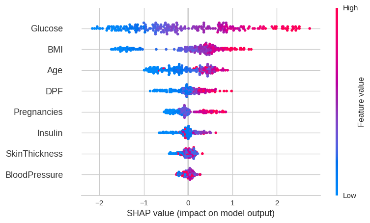

```python
interpret_model(catboost)
```

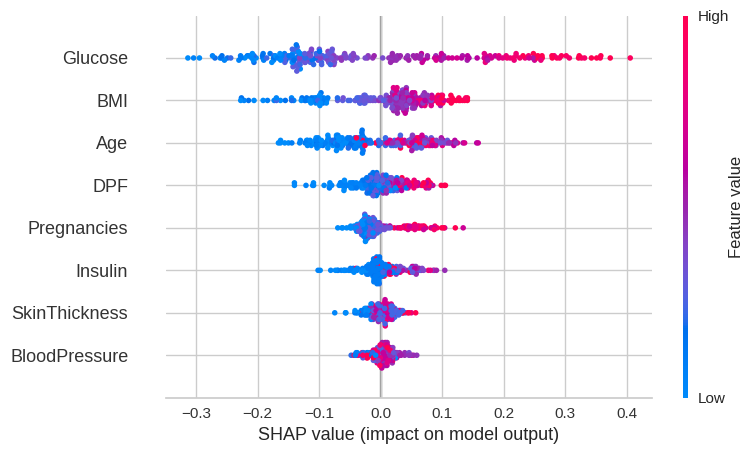

```python
interpret_model(rf)
```

Observation:

As expected, glucose is used as the most important feature. SkinTickness and BloodPressure have the low importance.

Tuning Hyperparameters

> This function tunes the hyperparameters of a given estimator. The output of this function is a score grid with CV scores by fold of the best selected model based on optimize parameter.

```python
tuned_catboost = tune_model(catboost, optimize = 'AUC')
tuned_rf = tune_model(rf, optimize = 'AUC')
tuned_lr = tune_model(lr, optimize = 'AUC')
tuned_lda = tune_model(lda, optimize = 'AUC')
tuned_gbc = tune_model(gbc, optimize = 'AUC')
```

| Fold | Accuracy | AUC | Recall | Prec. | F1 | Kappa | MCC |
| --- | --- | --- | --- | --- | --- | --- | --- |
| 0 | 0.7778 | 0.7699 | 0.6842 | 0.6842 | 0.6842 | 0.5128 | 0.5128 |
| 1 | 0.7963 | 0.8541 | 0.6842 | 0.7222 | 0.7027 | 0.5479 | 0.5484 |
| 2 | 0.7963 | 0.8782 | 0.5789 | 0.7857 | 0.6667 | 0.5248 | 0.5375 |
| 3 | 0.7963 | 0.8857 | 0.6316 | 0.7500 | 0.6857 | 0.5367 | 0.5410 |
| 4 | 0.7778 | 0.8271 | 0.5789 | 0.7333 | 0.6471 | 0.4882 | 0.4954 |
| 5 | 0.7222 | 0.8030 | 0.7368 | 0.5833 | 0.6512 | 0.4255 | 0.4336 |
| 6 | 0.8333 | 0.8782 | 0.7895 | 0.7500 | 0.7692 | 0.6389 | 0.6394 |
| 7 | 0.8302 | 0.8270 | 0.6667 | 0.8000 | 0.7273 | 0.6055 | 0.6108 |
| 8 | 0.8491 | 0.9095 | 0.7222 | 0.8125 | 0.7647 | 0.6542 | 0.6566 |
| 9 | 0.6604 | 0.7429 | 0.3333 | 0.5000 | 0.4000 | 0.1762 | 0.1832 |
| Mean | 0.7840 | 0.8376 | 0.6406 | 0.7121 | 0.6699 | 0.5111 | 0.5159 |
| Std | 0.0533 | 0.0510 | 0.1203 | 0.0943 | 0.0987 | 0.1296 | 0.1281 |

```
Fitting 10 folds for each of 10 candidates, totalling 100 fits
```

| Fold | Accuracy | AUC | Recall | Prec. | F1 | Kappa | MCC |
| --- | --- | --- | --- | --- | --- | --- | --- |
| 0 | 0.7407 | 0.8015 | 0.7368 | 0.6087 | 0.6667 | 0.4577 | 0.4633 |
| 1 | 0.8148 | 0.8722 | 0.8421 | 0.6957 | 0.7619 | 0.6126 | 0.6201 |
| 2 | 0.7963 | 0.8647 | 0.7895 | 0.6818 | 0.7317 | 0.5689 | 0.5729 |
| 3 | 0.8148 | 0.8842 | 0.7895 | 0.7143 | 0.7500 | 0.6035 | 0.6054 |
| 4 | 0.8333 | 0.8316 | 0.8421 | 0.7273 | 0.7805 | 0.6473 | 0.6518 |
| 5 | 0.7407 | 0.8075 | 0.8421 | 0.5926 | 0.6957 | 0.4815 | 0.5041 |
| 6 | 0.8519 | 0.9008 | 0.8421 | 0.7619 | 0.8000 | 0.6828 | 0.6850 |
| 7 | 0.7547 | 0.8286 | 0.6667 | 0.6316 | 0.6486 | 0.4605 | 0.4609 |
| 8 | 0.8302 | 0.9079 | 0.8333 | 0.7143 | 0.7692 | 0.6362 | 0.6409 |
| 9 | 0.6981 | 0.7238 | 0.6111 | 0.5500 | 0.5789 | 0.3447 | 0.3458 |
| Mean | 0.7876 | 0.8423 | 0.7795 | 0.6678 | 0.7183 | 0.5496 | 0.5550 |
| Std | 0.0480 | 0.0530 | 0.0785 | 0.0648 | 0.0661 | 0.1025 | 0.1022 |

```
Fitting 10 folds for each of 10 candidates, totalling 100 fits
```

| Fold | Accuracy | AUC | Recall | Prec. | F1 | Kappa | MCC |
| --- | --- | --- | --- | --- | --- | --- | --- |
| 0 | 0.7222 | 0.8075 | 0.5263 | 0.6250 | 0.5714 | 0.3682 | 0.3711 |
| 1 | 0.7593 | 0.8361 | 0.6316 | 0.6667 | 0.6486 | 0.4658 | 0.4661 |
| 2 | 0.7963 | 0.8632 | 0.5263 | 0.8333 | 0.6452 | 0.5123 | 0.5389 |
| 3 | 0.8148 | 0.8827 | 0.6316 | 0.8000 | 0.7059 | 0.5735 | 0.5820 |
| 4 | 0.7963 | 0.8195 | 0.5789 | 0.7857 | 0.6667 | 0.5248 | 0.5375 |
| 5 | 0.7407 | 0.8090 | 0.7368 | 0.6087 | 0.6667 | 0.4577 | 0.4633 |
| 6 | 0.7778 | 0.8662 | 0.6316 | 0.7059 | 0.6667 | 0.5008 | 0.5025 |
| 7 | 0.7925 | 0.8397 | 0.4444 | 0.8889 | 0.5926 | 0.4734 | 0.5245 |
| 8 | 0.8302 | 0.8794 | 0.6111 | 0.8462 | 0.7097 | 0.5940 | 0.6098 |
| 9 | 0.7358 | 0.7889 | 0.3889 | 0.7000 | 0.5000 | 0.3399 | 0.3670 |
| Mean | 0.7766 | 0.8392 | 0.5708 | 0.7460 | 0.6373 | 0.4810 | 0.4963 |
| Std | 0.0340 | 0.0311 | 0.0966 | 0.0928 | 0.0616 | 0.0762 | 0.0768 |

```
Fitting 10 folds for each of 10 candidates, totalling 100 fits
```

| Fold | Accuracy | AUC | Recall | Prec. | F1 | Kappa | MCC |
| --- | --- | --- | --- | --- | --- | --- | --- |
| 0 | 0.7037 | 0.7970 | 0.5263 | 0.5882 | 0.5556 | 0.3344 | 0.3355 |
| 1 | 0.7407 | 0.8286 | 0.5789 | 0.6471 | 0.6111 | 0.4176 | 0.4190 |
| 2 | 0.7778 | 0.8632 | 0.4737 | 0.8182 | 0.6000 | 0.4609 | 0.4939 |
| 3 | 0.8333 | 0.8737 | 0.6316 | 0.8571 | 0.7273 | 0.6112 | 0.6260 |
| 4 | 0.7222 | 0.8090 | 0.5263 | 0.6250 | 0.5714 | 0.3682 | 0.3711 |
| 5 | 0.7222 | 0.8060 | 0.6842 | 0.5909 | 0.6341 | 0.4122 | 0.4151 |
| 6 | 0.8148 | 0.8632 | 0.6316 | 0.8000 | 0.7059 | 0.5735 | 0.5820 |
| 7 | 0.7925 | 0.8444 | 0.4444 | 0.8889 | 0.5926 | 0.4734 | 0.5245 |
| 8 | 0.8302 | 0.8968 | 0.6111 | 0.8462 | 0.7097 | 0.5940 | 0.6098 |
| 9 | 0.7358 | 0.7667 | 0.3889 | 0.7000 | 0.5000 | 0.3399 | 0.3670 |
| Mean | 0.7673 | 0.8349 | 0.5497 | 0.7362 | 0.6208 | 0.4585 | 0.4744 |
| Std | 0.0460 | 0.0383 | 0.0894 | 0.1120 | 0.0702 | 0.0983 | 0.1019 |

```
Fitting 10 folds for each of 10 candidates, totalling 100 fits
```

```
Original model was better than the tuned model, hence it will be returned. NOTE: The display metrics are for the tuned model (not the original one).
```

| Fold | Accuracy | AUC | Recall | Prec. | F1 | Kappa | MCC |
| --- | --- | --- | --- | --- | --- | --- | --- |
| 0 | 0.6481 | 0.7684 | 0.0000 | 0.0000 | 0.0000 | 0.0000 | 0.0000 |
| 1 | 0.6481 | 0.8617 | 0.0000 | 0.0000 | 0.0000 | 0.0000 | 0.0000 |
| 2 | 0.6481 | 0.8737 | 0.0000 | 0.0000 | 0.0000 | 0.0000 | 0.0000 |
| 3 | 0.6481 | 0.8812 | 0.0000 | 0.0000 | 0.0000 | 0.0000 | 0.0000 |
| 4 | 0.6481 | 0.8391 | 0.0000 | 0.0000 | 0.0000 | 0.0000 | 0.0000 |
| 5 | 0.6481 | 0.7985 | 0.0000 | 0.0000 | 0.0000 | 0.0000 | 0.0000 |
| 6 | 0.6481 | 0.9038 | 0.0000 | 0.0000 | 0.0000 | 0.0000 | 0.0000 |
| 7 | 0.6604 | 0.8397 | 0.0000 | 0.0000 | 0.0000 | 0.0000 | 0.0000 |
| 8 | 0.6604 | 0.8984 | 0.0000 | 0.0000 | 0.0000 | 0.0000 | 0.0000 |
| 9 | 0.6604 | 0.7667 | 0.0000 | 0.0000 | 0.0000 | 0.0000 | 0.0000 |
| Mean | 0.6518 | 0.8431 | 0.0000 | 0.0000 | 0.0000 | 0.0000 | 0.0000 |
| Std | 0.0056 | 0.0479 | 0.0000 | 0.0000 | 0.0000 | 0.0000 | 0.0000 |

```
Fitting 10 folds for each of 10 candidates, totalling 100 fits
```

# Stacking

```python
stack_model = stack_models(estimator_list = top5, meta_model = top5[0],optimize = 'AUC')
```

| Fold | Accuracy | AUC | Recall | Prec. | F1 | Kappa | MCC |
| --- | --- | --- | --- | --- | --- | --- | --- |
| 0 | 0.7407 | 0.8120 | 0.5789 | 0.6471 | 0.6111 | 0.4176 | 0.4190 |
| 1 | 0.7593 | 0.8496 | 0.6316 | 0.6667 | 0.6486 | 0.4658 | 0.4661 |
| 2 | 0.7778 | 0.8617 | 0.5263 | 0.7692 | 0.6250 | 0.4749 | 0.4921 |
| 3 | 0.7963 | 0.8842 | 0.5789 | 0.7857 | 0.6667 | 0.5248 | 0.5375 |
| 4 | 0.7963 | 0.8301 | 0.5789 | 0.7857 | 0.6667 | 0.5248 | 0.5375 |
| 5 | 0.7222 | 0.8075 | 0.6842 | 0.5909 | 0.6341 | 0.4122 | 0.4151 |
| 6 | 0.7778 | 0.8722 | 0.6316 | 0.7059 | 0.6667 | 0.5008 | 0.5025 |
| 7 | 0.7925 | 0.8397 | 0.4444 | 0.8889 | 0.5926 | 0.4734 | 0.5245 |
| 8 | 0.8302 | 0.8746 | 0.6111 | 0.8462 | 0.7097 | 0.5940 | 0.6098 |
| 9 | 0.6792 | 0.7889 | 0.3889 | 0.5385 | 0.4516 | 0.2332 | 0.2394 |
| Mean | 0.7672 | 0.8420 | 0.5655 | 0.7225 | 0.6273 | 0.4621 | 0.4744 |
| Std | 0.0413 | 0.0304 | 0.0853 | 0.1065 | 0.0665 | 0.0916 | 0.0958 |

The top 5 models can be stacked using the stack_models() function. This will create a meta-model that takes the outputs of the top 5 models as inputs and makes the final prediction. The optimize parameter The optimize parameter is set to 'AUC' to optimize the stacked model using AUC.

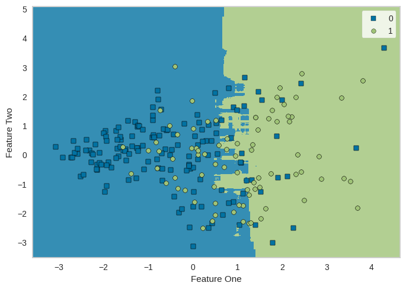

```python
plt.figure(figsize=(8, 8))
plot_model(stack_model, plot='boundary')
```

In the case of a stacking model, in some cases overfitting and in some cases underfitting.

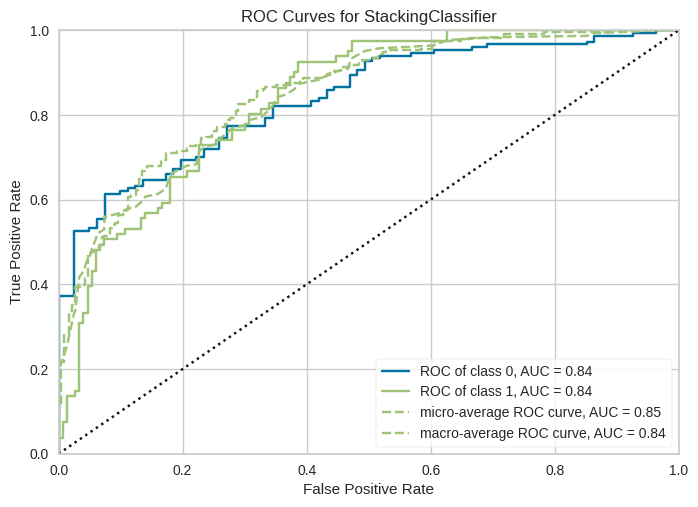

```python
plt.figure(figsize=(8, 8))
plot_model(stack_model, plot = 'auc')
```

The AUC score of the stacking model is pretty good for both classes, with an AUC of 0.84 for both class 0 and class 1. This indicates that the model has good predictive performance.

```python
#prediction
pred = stack_model.predict(X_test)
pred_proba = stack_model.predict_proba(X_test)[:,1]
#Accuracy
confusion_stack = get_clf_eval(y_test,pred,pred_proba)
```

```
accuracy: 0.8073, precision: 0.7667, recall: 0.6667,    F1: 0.7132, AUC:0.8908
```

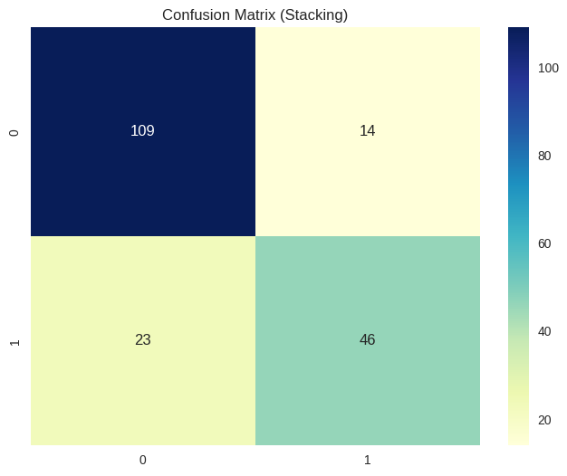

```python
plt.figure(figsize=(8, 6))
ax = sns.heatmap(confusion_stack, cmap = 'YlGnBu',annot = True, fmt='d')
ax.set_title('Confusion Matrix (Stacking)')
```

Precision and recall have a trade-off relationship. The picture above seems to be well balanced because it has been studied well.

# Soft Voting

Soft voting is a technique in which the predicted probabilities of each model are averaged to make the final prediction. In this way, the output of each model is taken into account and the final prediction is made based on a weighted average of the predictions of the models.

```python
blend_soft = blend_models(estimator_list = top5, optimize = 'AUC',method = 'soft')
```

| Fold | Accuracy | AUC | Recall | Prec. | F1 | Kappa | MCC |
| --- | --- | --- | --- | --- | --- | --- | --- |
| 0 | 0.7037 | 0.8135 | 0.5789 | 0.5789 | 0.5789 | 0.3504 | 0.3504 |
| 1 | 0.7963 | 0.8571 | 0.7368 | 0.7000 | 0.7179 | 0.5587 | 0.5591 |
| 2 | 0.7778 | 0.8677 | 0.5263 | 0.7692 | 0.6250 | 0.4749 | 0.4921 |
| 3 | 0.7778 | 0.8917 | 0.5789 | 0.7333 | 0.6471 | 0.4882 | 0.4954 |
| 4 | 0.7593 | 0.8391 | 0.5263 | 0.7143 | 0.6061 | 0.4384 | 0.4490 |
| 5 | 0.7222 | 0.8120 | 0.6842 | 0.5909 | 0.6341 | 0.4122 | 0.4151 |
| 6 | 0.7778 | 0.8842 | 0.6842 | 0.6842 | 0.6842 | 0.5128 | 0.5128 |
| 7 | 0.8113 | 0.8556 | 0.5000 | 0.9000 | 0.6429 | 0.5285 | 0.5706 |
| 8 | 0.8491 | 0.8714 | 0.6667 | 0.8571 | 0.7500 | 0.6443 | 0.6547 |
| 9 | 0.6604 | 0.7921 | 0.3333 | 0.5000 | 0.4000 | 0.1762 | 0.1832 |
| Mean | 0.7636 | 0.8484 | 0.5816 | 0.7028 | 0.6286 | 0.4584 | 0.4682 |
| Std | 0.0522 | 0.0316 | 0.1126 | 0.1173 | 0.0904 | 0.1214 | 0.1246 |

The output shows the performance metrics of the 10-fold cross-validation for the soft voting ensemble method.

Accuracy: The average accuracy of the model is 76.36%.

AUC: The average AUC score of the model is 0.8484.

Recall: The average recall score of the model is 0.5816.

Precision: The average precision score of the model is 0.7028.

F1: The average F1 score of the model is 0.6286.

Kappa: The average kappa score of the model is 0.4584.

MCC: The average Matthews correlation coefficient (MCC) score of the model is 0.4682.

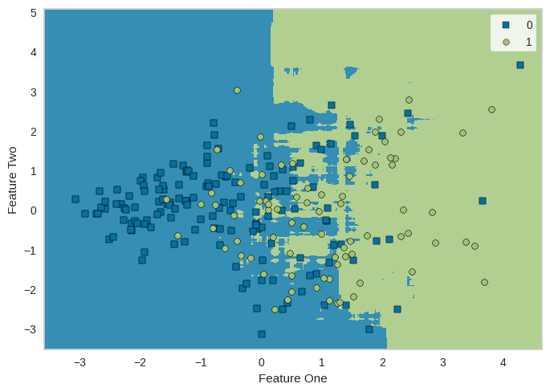

```python
plt.figure(figsize=(8, 8))
plot_model(blend_soft, plot='boundary')
```

Here, it looks like the model has been properly trained.

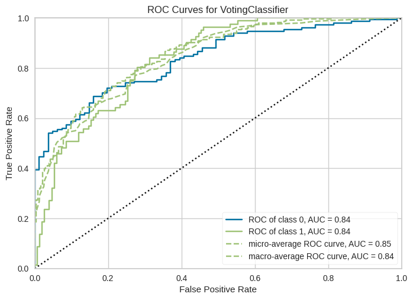

```python
plt.figure(figsize=(8, 8))
plot_model(blend_soft, plot = 'auc')
```

```python
#prediction
pred = blend_soft.predict(X_test)
pred_proba = blend_soft.predict_proba(X_test)[:,1]
#Accuracy
confusion_soft = get_clf_eval(y_test,pred,pred_proba)
```

```
accuracy: 0.8958, precision: 0.8889, recall: 0.8116,    F1: 0.8485, AUC:0.9584
```

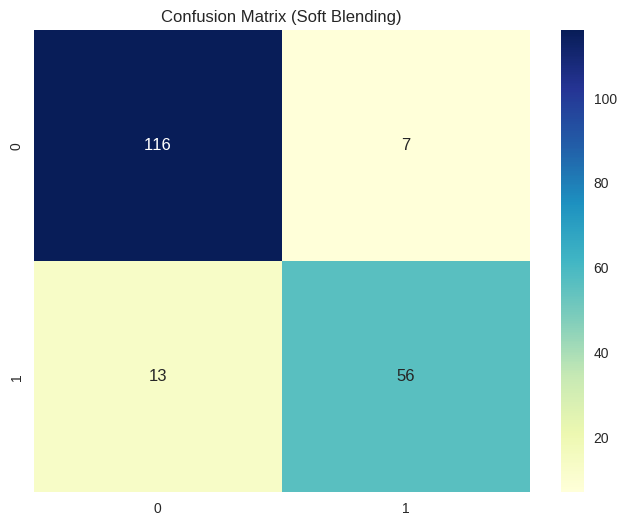

```python
plt.figure(figsize=(8, 6))
ax = sns.heatmap(confusion_soft, cmap = 'YlGnBu',annot = True, fmt='d')
ax.set_title('Confusion Matrix (Soft Blending)')
```

The confusion matrix is also well balanced and the results are good.

## Hard Voting

```python
blend_hard = blend_models(estimator_list = top5, optimize = 'AUC',method = 'hard')
```

| Fold | Accuracy | AUC | Recall | Prec. | F1 | Kappa | MCC |
| --- | --- | --- | --- | --- | --- | --- | --- |
| 0 | 0.7037 | 0.0000 | 0.5789 | 0.5789 | 0.5789 | 0.3504 | 0.3504 |
| 1 | 0.7963 | 0.0000 | 0.6842 | 0.7222 | 0.7027 | 0.5479 | 0.5484 |
| 2 | 0.8148 | 0.0000 | 0.5789 | 0.8462 | 0.6875 | 0.5624 | 0.5828 |
| 3 | 0.7778 | 0.0000 | 0.5789 | 0.7333 | 0.6471 | 0.4882 | 0.4954 |
| 4 | 0.7778 | 0.0000 | 0.5263 | 0.7692 | 0.6250 | 0.4749 | 0.4921 |
| 5 | 0.7222 | 0.0000 | 0.6842 | 0.5909 | 0.6341 | 0.4122 | 0.4151 |
| 6 | 0.7963 | 0.0000 | 0.6842 | 0.7222 | 0.7027 | 0.5479 | 0.5484 |
| 7 | 0.7925 | 0.0000 | 0.5000 | 0.8182 | 0.6207 | 0.4890 | 0.5171 |
| 8 | 0.8491 | 0.0000 | 0.6667 | 0.8571 | 0.7500 | 0.6443 | 0.6547 |
| 9 | 0.6981 | 0.0000 | 0.4444 | 0.5714 | 0.5000 | 0.2886 | 0.2933 |
| Mean | 0.7729 | 0.0000 | 0.5927 | 0.7210 | 0.6449 | 0.4806 | 0.4898 |
| Std | 0.0469 | 0.0000 | 0.0813 | 0.1028 | 0.0678 | 0.1006 | 0.1035 |

The hard voting ensemble model has an average accuracy of 77.29%, with a standard deviation of 4.69%.

The AUC score is 0.

The recall ranges from 44.44% to 68.42%, with an average of 59.27%.

The precision ranges from 57.14% to 85.71%, with an average of 72.10%.

The F1 score ranges from 50.00% to 75.00%, with an average of 64.49%.

The kappa score ranges from 28.86% to 64.43%, with an average of 48.06%.

The MCC score ranges from 29.33% to 65.47%, with an average of 48.98%.

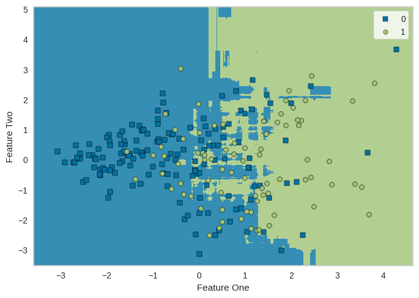

```python
plt.figure(figsize=(8, 8))
plot_model(blend_hard, plot='boundary')
```

This depicts how well the model has learned

## Predicting with the test dateset

```python
#prediction
pred = blend_hard.predict(X_test)
#Accuracy
confusion_hard = confusion_matrix( y_test, pred)
accuracy = accuracy_score(y_test , pred)
precision = precision_score(y_test , pred)
recall = recall_score(y_test , pred)
f1 = f1_score(y_test,pred)
print('accuracy: {0:.4f}, precision: {1:.4f}, recall: {2:.4f},\
F1: {3:.4f}'.format(accuracy, precision, recall, f1))
```

```
accuracy: 0.9010, precision: 0.8788, recall: 0.8406,F1: 0.8593
```

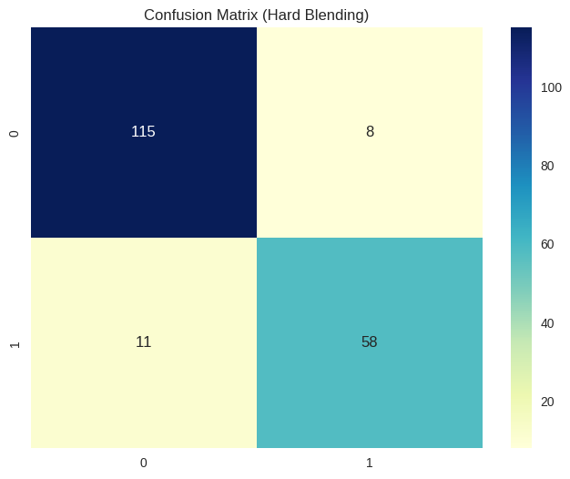

```python
plt.figure(figsize=(8, 6))
ax = sns.heatmap(confusion_hard, cmap = 'YlGnBu',annot = True, fmt='d')
ax.set_title('Confusion Matrix (Hard Blending)')
```

# Calibrating the final model

```python
cali_model = calibrate_model(blend_soft)
```

| Fold | Accuracy | AUC | Recall | Prec. | F1 | Kappa | MCC |
| --- | --- | --- | --- | --- | --- | --- | --- |
| 0 | 0.7407 | 0.8075 | 0.5789 | 0.6471 | 0.6111 | 0.4176 | 0.4190 |
| 1 | 0.7963 | 0.8586 | 0.6842 | 0.7222 | 0.7027 | 0.5479 | 0.5484 |
| 2 | 0.7778 | 0.8647 | 0.5263 | 0.7692 | 0.6250 | 0.4749 | 0.4921 |
| 3 | 0.7778 | 0.8947 | 0.5789 | 0.7333 | 0.6471 | 0.4882 | 0.4954 |
| 4 | 0.7593 | 0.8421 | 0.5263 | 0.7143 | 0.6061 | 0.4384 | 0.4490 |
| 5 | 0.7407 | 0.8120 | 0.6842 | 0.6190 | 0.6500 | 0.4449 | 0.4463 |
| 6 | 0.7778 | 0.8797 | 0.6842 | 0.6842 | 0.6842 | 0.5128 | 0.5128 |
| 7 | 0.8113 | 0.8429 | 0.5000 | 0.9000 | 0.6429 | 0.5285 | 0.5706 |
| 8 | 0.8491 | 0.8857 | 0.6667 | 0.8571 | 0.7500 | 0.6443 | 0.6547 |
| 9 | 0.6604 | 0.7984 | 0.3333 | 0.5000 | 0.4000 | 0.1762 | 0.1832 |
| Mean | 0.7691 | 0.8486 | 0.5763 | 0.7147 | 0.6319 | 0.4674 | 0.4772 |
| Std | 0.0476 | 0.0323 | 0.1063 | 0.1090 | 0.0879 | 0.1152 | 0.1178 |

'calibrate_model' function in PyCaret is used to calibrate the predicted probabilities of a trained classification model. It applies isotonic regression or sigmoid calibration technique to improve the accuracy of predicted probabilities.After calibration, the calibrated model can be used to make predictions that are more accurate and can provide better insight into the underlying probabilities of the target class.

## Finalizing the last mode

```python
final_model = finalize_model(cali_model)
```

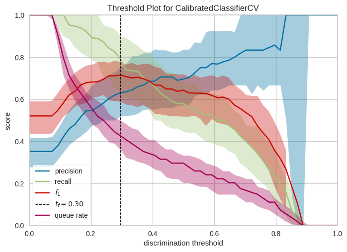

```python
plt.figure(figsize=(8, 8))
plot_model(final_model, plot='threshold')
```

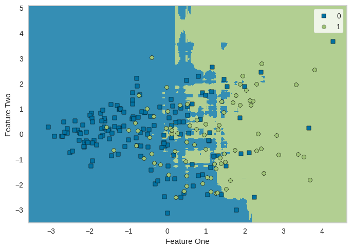

```python
plt.figure(figsize=(8, 8))
plot_model(final_model, plot='boundary')
```

```python
#prediction
pred = final_model.predict(X_test)
#Accuracy
final_model = confusion_matrix( y_test, pred)
accuracy = accuracy_score(y_test , pred)
precision = precision_score(y_test , pred)
recall = recall_score(y_test , pred)
f1 = f1_score(y_test,pred)
print('accuracy: {0:.4f}, precision: {1:.4f}, recall: {2:.4f},\
F1: {3:.4f}'.format(accuracy, precision, recall, f1))
```

```
accuracy: 0.9375, precision: 0.9524, recall: 0.8696,F1: 0.9091
```

[figure not shown]

```python
plt.figure(figsize=(8, 6))
ax = sns.heatmap(confusion_hard, cmap = 'YlGnBu',annot = True, fmt='d')
ax.set_title('Confusion Matrix (final_model)')
```

# Conclusion

> Following EDA and preprocessing, we trained three ensemble models and evaluated their performance using the validation dataset. The ensembles using soft and hard voting showed the best results for this problem. However, the choice of preprocessing techniques, base models, and hyperparameters can influence the results and may vary for different datasets.